# Martinez_20173026

1. Importamos las librerías que se utilizarán a lo largo del trabajo

```python
import pandas as pd
import numpy as np
import matplotlib.pyplot as plt
```

```python
df_positivos = pd.read_csv( "positivos_covid.csv", sep = ";" ,encoding = 'UTF-8')
```

1. Análisis de los dataframes

```python
df_positivos.dtypes
```

```
FECHA_CORTE          int64
UUID                object
DEPARTAMENTO        object
PROVINCIA           object
DISTRITO            object
METODODX            object
EDAD               float64
SEXO                object
FECHA_RESULTADO    float64
dtype: object
```

```python
df_positivos.describe()
```

|  | FECHA_CORTE | EDAD | FECHA_RESULTADO |
| --- | --- | --- | --- |
| count | 2065113.0 | 2.064769e+06 | 2.063090e+06 |
| mean | 20210703.0 | 4.220716e+01 | 2.020561e+07 |
| std | 0.0 | 1.770383e+01 | 4.785085e+03 |
| min | 20210703.0 | -7.900000e+01 | 2.020031e+07 |
| 25% | 20210703.0 | 2.900000e+01 | 2.020081e+07 |
| 50% | 20210703.0 | 4.000000e+01 | 2.021011e+07 |
| 75% | 20210703.0 | 5.400000e+01 | 2.021033e+07 |
| max | 20210703.0 | 1.210000e+02 | 2.021070e+07 |

```python
df_positivos.describe(include="O")
```

|  | UUID | DEPARTAMENTO | PROVINCIA | DISTRITO | METODODX | SEXO |
| --- | --- | --- | --- | --- | --- | --- |
| count | 2065113 | 2065113 | 2065113 | 2065113 | 2065113 | 2065112 |
| unique | 2065113 | 26 | 197 | 1697 | 3 | 2 |
| top | a79fd0ef5e55692aa9c2ab0bc45e732a | LIMA | LIMA | EN INVESTIGACIÓN | PR | MASCULINO |
| freq | 1 | 842723 | 773667 | 105843 | 933643 | 1059060 |

```python
df_positivos.head()
```

|  | FECHA_CORTE | UUID | DEPARTAMENTO | PROVINCIA | DISTRITO | METODODX | EDAD | SEXO | FECHA_RESULTADO |
| --- | --- | --- | --- | --- | --- | --- | --- | --- | --- |
| 0 | 20210703 | 7320cabdc1aaca6c59014cae76a134e6 | LAMBAYEQUE | FERREÑAFE | FERREÑAFE | PR | 35.0 | FEMENINO | 20200329.0 |
| 1 | 20210703 | cecdbf10074dbc011ae05b3cbd320a6f | LIMA | LIMA | CHORRILLOS | PR | 36.0 | MASCULINO | 20200330.0 |
| 2 | 20210703 | 71ecb6bccb248b0bb2ac72ed51b5e979 | LIMA | LIMA | LIMA | PR | 1.0 | FEMENINO | 20200330.0 |
| 3 | 20210703 | 566af4276cbe9359abe93f9aa86396c3 | LIMA | LIMA | LIMA | PR | 65.0 | FEMENINO | 20200330.0 |
| 4 | 20210703 | 027561e9d126e7c283d79c02cede562d | LIMA | LIMA | LIMA | PR | 32.0 | FEMENINO | 20200330.0 |

1. Limpiando las bases de datos

```python
# Eliminando los valores missings

df_positivos.shape
```

```
(2065113, 9)
```

```python
# cuántos nulos tienen la base

df_positivos.isnull().sum(axis = 0)
```

```
FECHA_CORTE           0
UUID                  0
DEPARTAMENTO          0
PROVINCIA             0
DISTRITO              0
METODODX              0
EDAD                344
SEXO                  1
FECHA_RESULTADO    2023
dtype: int64
```

```python
df_positivos = df_positivos.dropna()
```

```python
df_positivos.isnull().sum(axis = 0)
```

```
FECHA_CORTE        0
UUID               0
DEPARTAMENTO       0
PROVINCIA          0
DISTRITO           0
METODODX           0
EDAD               0
SEXO               0
FECHA_RESULTADO    0
dtype: int64
```

```python
#Se eliminaron los valores missings
df_positivos.shape
```

```
(2062745, 9)
```

```python
# Cambiando de formato a las variable de fechas
df_positivos["FECHA_RESULTADO"] = df_positivos["FECHA_RESULTADO"].astype(int).astype(str)

df_positivos["FECHA"] =  pd.to_datetime( df_positivos["FECHA_RESULTADO"],
                                         format= '%Y%m%d', errors = "coerce")
```

```python
df_positivos.head()
```

|  | FECHA_CORTE | UUID | DEPARTAMENTO | PROVINCIA | DISTRITO | METODODX | EDAD | SEXO | FECHA_RESULTADO | FECHA |
| --- | --- | --- | --- | --- | --- | --- | --- | --- | --- | --- |
| 0 | 20210703 | 7320cabdc1aaca6c59014cae76a134e6 | LAMBAYEQUE | FERREÑAFE | FERREÑAFE | PR | 35.0 | FEMENINO | 20200329 | 2020-03-29 |
| 1 | 20210703 | cecdbf10074dbc011ae05b3cbd320a6f | LIMA | LIMA | CHORRILLOS | PR | 36.0 | MASCULINO | 20200330 | 2020-03-30 |
| 2 | 20210703 | 71ecb6bccb248b0bb2ac72ed51b5e979 | LIMA | LIMA | LIMA | PR | 1.0 | FEMENINO | 20200330 | 2020-03-30 |
| 3 | 20210703 | 566af4276cbe9359abe93f9aa86396c3 | LIMA | LIMA | LIMA | PR | 65.0 | FEMENINO | 20200330 | 2020-03-30 |
| 4 | 20210703 | 027561e9d126e7c283d79c02cede562d | LIMA | LIMA | LIMA | PR | 32.0 | FEMENINO | 20200330 | 2020-03-30 |

```python
df_positivos["EDAD"] = df_positivos["EDAD"].astype(int)
```

```python
df_positivos.head()
```

|  | FECHA_CORTE | UUID | DEPARTAMENTO | PROVINCIA | DISTRITO | METODODX | EDAD | SEXO | FECHA_RESULTADO | FECHA |
| --- | --- | --- | --- | --- | --- | --- | --- | --- | --- | --- |
| 0 | 20210703 | 7320cabdc1aaca6c59014cae76a134e6 | LAMBAYEQUE | FERREÑAFE | FERREÑAFE | PR | 35 | FEMENINO | 20200329 | 2020-03-29 |
| 1 | 20210703 | cecdbf10074dbc011ae05b3cbd320a6f | LIMA | LIMA | CHORRILLOS | PR | 36 | MASCULINO | 20200330 | 2020-03-30 |
| 2 | 20210703 | 71ecb6bccb248b0bb2ac72ed51b5e979 | LIMA | LIMA | LIMA | PR | 1 | FEMENINO | 20200330 | 2020-03-30 |
| 3 | 20210703 | 566af4276cbe9359abe93f9aa86396c3 | LIMA | LIMA | LIMA | PR | 65 | FEMENINO | 20200330 | 2020-03-30 |
| 4 | 20210703 | 027561e9d126e7c283d79c02cede562d | LIMA | LIMA | LIMA | PR | 32 | FEMENINO | 20200330 | 2020-03-30 |

```python
#Dummies para metodo de prueba y sexo

df_positivos = pd.get_dummies(df_positivos, columns = ['METODODX',"SEXO"])
```

```python
df_positivos.head()
```

|  | FECHA_CORTE | UUID | DEPARTAMENTO | PROVINCIA | DISTRITO | EDAD | FECHA_RESULTADO | FECHA | METODODX_AG | METODODX_PCR | METODODX_PR | SEXO_FEMENINO | SEXO_MASCULINO |
| --- | --- | --- | --- | --- | --- | --- | --- | --- | --- | --- | --- | --- | --- |
| 0 | 20210703 | 7320cabdc1aaca6c59014cae76a134e6 | LAMBAYEQUE | FERREÑAFE | FERREÑAFE | 35 | 20200329 | 2020-03-29 | 0 | 0 | 1 | 1 | 0 |
| 1 | 20210703 | cecdbf10074dbc011ae05b3cbd320a6f | LIMA | LIMA | CHORRILLOS | 36 | 20200330 | 2020-03-30 | 0 | 0 | 1 | 0 | 1 |
| 2 | 20210703 | 71ecb6bccb248b0bb2ac72ed51b5e979 | LIMA | LIMA | LIMA | 1 | 20200330 | 2020-03-30 | 0 | 0 | 1 | 1 | 0 |
| 3 | 20210703 | 566af4276cbe9359abe93f9aa86396c3 | LIMA | LIMA | LIMA | 65 | 20200330 | 2020-03-30 | 0 | 0 | 1 | 1 | 0 |
| 4 | 20210703 | 027561e9d126e7c283d79c02cede562d | LIMA | LIMA | LIMA | 32 | 20200330 | 2020-03-30 | 0 | 0 | 1 | 1 | 0 |

```python
#Fecha de resultado en mes
df_positivos['MES'] = df_positivos['FECHA'].dt.strftime('%Y%m').astype(int) #YYYYMM
```

```python
df_positivos.dtypes
```

```
FECHA_CORTE                 int64
UUID                       object
DEPARTAMENTO               object
PROVINCIA                  object
DISTRITO                   object
EDAD                        int32
FECHA_RESULTADO            object
FECHA              datetime64[ns]
METODODX_AG                 uint8
METODODX_PCR                uint8
METODODX_PR                 uint8
SEXO_FEMENINO               uint8
SEXO_MASCULINO              uint8
MES                         int32
dtype: object
```

```python
df_positivos.head()
```

|  | FECHA_CORTE | UUID | DEPARTAMENTO | PROVINCIA | DISTRITO | EDAD | FECHA_RESULTADO | FECHA | METODODX_AG | METODODX_PCR | METODODX_PR | SEXO_FEMENINO | SEXO_MASCULINO | MES |
| --- | --- | --- | --- | --- | --- | --- | --- | --- | --- | --- | --- | --- | --- | --- |
| 0 | 20210703 | 7320cabdc1aaca6c59014cae76a134e6 | LAMBAYEQUE | FERREÑAFE | FERREÑAFE | 35 | 20200329 | 2020-03-29 | 0 | 0 | 1 | 1 | 0 | 202003 |
| 1 | 20210703 | cecdbf10074dbc011ae05b3cbd320a6f | LIMA | LIMA | CHORRILLOS | 36 | 20200330 | 2020-03-30 | 0 | 0 | 1 | 0 | 1 | 202003 |
| 2 | 20210703 | 71ecb6bccb248b0bb2ac72ed51b5e979 | LIMA | LIMA | LIMA | 1 | 20200330 | 2020-03-30 | 0 | 0 | 1 | 1 | 0 | 202003 |
| 3 | 20210703 | 566af4276cbe9359abe93f9aa86396c3 | LIMA | LIMA | LIMA | 65 | 20200330 | 2020-03-30 | 0 | 0 | 1 | 1 | 0 | 202003 |
| 4 | 20210703 | 027561e9d126e7c283d79c02cede562d | LIMA | LIMA | LIMA | 32 | 20200330 | 2020-03-30 | 0 | 0 | 1 | 1 | 0 | 202003 |

```python
df_positivos_consolidado = df_positivos.groupby(['MES','DEPARTAMENTO']).agg(
    {'METODODX_AG':['sum'],
     'METODODX_PCR':['sum'],
     'METODODX_PR':['sum'],
     'SEXO_FEMENINO':['sum'],
     'SEXO_MASCULINO' : ['sum']} )
```

```python
df_positivos_consolidado.head()
```

| MES | DEPARTAMENTO | METODODX_AG sum | METODODX_PCR sum | METODODX_PR sum | SEXO_FEMENINO sum | SEXO_MASCULINO sum |
| --- | --- | --- | --- | --- | --- | --- |
| 202003 | ANCASH | 0.0 | 13.0 | 0.0 | 5.0 | 8.0 |
|  | AREQUIPA | 0.0 | 30.0 | 0.0 | 15.0 | 15.0 |
|  | AYACUCHO | 0.0 | 1.0 | 0.0 | 0.0 | 1.0 |
|  | CAJAMARCA | 0.0 | 1.0 | 0.0 | 0.0 | 1.0 |
|  | CALLAO | 0.0 | 46.0 | 0.0 | 18.0 | 28.0 |

```python
df_positivos_consolidado.columns = ["antigenos","molecular","prueba_rapida","femenino","masculino"]
df_positivos_consolidado.reset_index(inplace=True)
```

```python
df_positivos_consolidado.head()
```

|  | MES | DEPARTAMENTO | antigenos | molecular | prueba_rapida | femenino | masculino |
| --- | --- | --- | --- | --- | --- | --- | --- |
| 0 | 202003 | ANCASH | 0.0 | 13.0 | 0.0 | 5.0 | 8.0 |
| 1 | 202003 | AREQUIPA | 0.0 | 30.0 | 0.0 | 15.0 | 15.0 |
| 2 | 202003 | AYACUCHO | 0.0 | 1.0 | 0.0 | 0.0 | 1.0 |
| 3 | 202003 | CAJAMARCA | 0.0 | 1.0 | 0.0 | 0.0 | 1.0 |
| 4 | 202003 | CALLAO | 0.0 | 46.0 | 0.0 | 18.0 | 28.0 |

```python
df_positivos_mensual = df_positivos_consolidado.groupby(["MES"]).sum()
df_positivos_mensual.reset_index(inplace=True)
```

```python
df_positivos_mensual.head()
```

|  | MES | antigenos | molecular | prueba_rapida | femenino | masculino |
| --- | --- | --- | --- | --- | --- | --- |
| 0 | 202003 | 0.0 | 1287.0 | 30.0 | 561.0 | 756.0 |
| 1 | 202004 | 0.0 | 14085.0 | 32413.0 | 17874.0 | 28624.0 |
| 2 | 202005 | 2.0 | 24079.0 | 107420.0 | 53276.0 | 78225.0 |
| 3 | 202006 | 4.0 | 33596.0 | 87923.0 | 56008.0 | 65515.0 |
| 4 | 202007 | 0.0 | 40278.0 | 103652.0 | 68464.0 | 75466.0 |

#### Gráfico 1

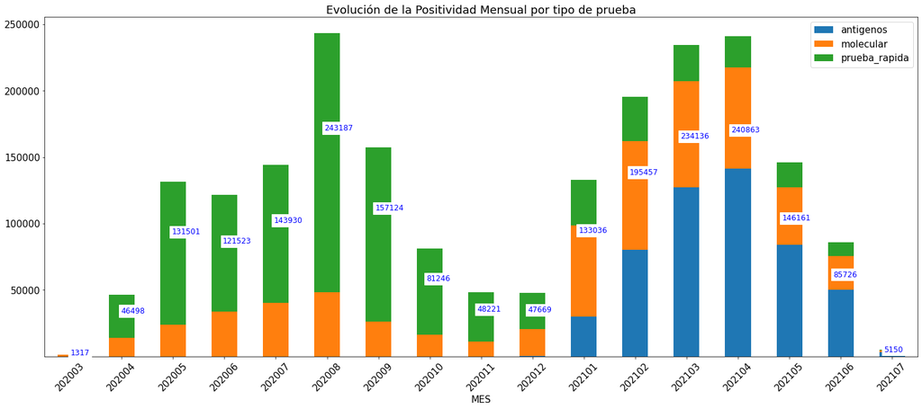

```python
plt.rcParams.update({'font.size': 15})  #configurando el tamaño de letra para los gráficos
plt.rcParams["figure.figsize"] = (25,10)
df_positivos_mensual.plot(x = "MES", y = ["antigenos","molecular","prueba_rapida"], kind ="bar",stacked =True)

plt.xticks(rotation = 45) #labels con rotacion
plt.title("Evolución de la Positividad Mensual por tipo de prueba")

#Añadiendo etiquetas con el número de contagios totales por prueba positiva
x = df_positivos_mensual["MES"]
y = df_positivos_mensual["antigenos"] + df_positivos_mensual["molecular"] + df_positivos_mensual["prueba_rapida"]

#Para mover la ubicación de las etiquetas con los datos totales
fx  = 0.99
fy = 0.7
for i, v in enumerate(x):
    plt.text(i*fx, y[i]*fy,str(int(y[i])), color='blue', backgroundcolor= "white",fontsize = 12 ,rotation = 0)

plt.show()
```

En este gráfico se puede observar que hasta finales del año 2020, la cantidad de pruebas rápidas que se utilizaban para descartar los casos positivos de COVID-19 eran utilizadas en mayor cantidad que la prueba molecular. Sin embargo, desde el año 2021, se comenzaron a emplear en mayor proporción las pruebas de antígenos, y se estuvo reduciendo paulatinamente el número de pruebas rápidas.

### Gráfico 2

```python
#Filtrando solo 2021 y sin contar Lima

condicion = (df_positivos_consolidado["MES"] >= 202101 ) & (df_positivos_consolidado["DEPARTAMENTO"] != "LIMA" )

#Agrupamos la base consolidada por departamento para ver la positividad en este periodo por sexo
df_positivos_consolidado_filtrado = df_positivos_consolidado[ condicion ]
df_positivos_dep = df_positivos_consolidado_filtrado.groupby(["DEPARTAMENTO"]).sum()
df_positivos_dep.reset_index(inplace=True)
```

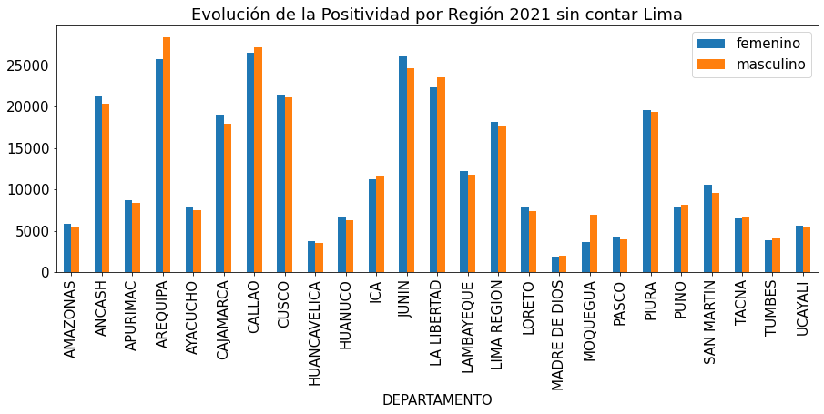

```python
plt.rcParams["figure.figsize"] = (15,5)
df_positivos_dep.plot(x="DEPARTAMENTO", y = ["femenino","masculino"], kind= "bar")

plt.title("Evolución de la Positividad por Región 2021 sin contar Lima")
ax.set_xticks(y)
ax.set_xticklabels(y)
ax.legend()

plt.show()
```

En este gráfico se puede ver que la cantidad de infectados por COVID-19 es casi similar entre hombres y mujeres. Hasta inicios de julio del año 2021, la mayor cantidad de infectados hombres se encuentra en Arequipa y Callao; y la mayor cantidad de infectadas mujeres se encuentra en Junín y Callao.

```python
df_positivos_dep.head()
```

[output not shown]

```python
df_positivos_dep.head()
```

|  | DEPARTAMENTO | MES | antigenos | molecular | prueba_rapida | femenino | masculino |
| --- | --- | --- | --- | --- | --- | --- | --- |
| 0 | AMAZONAS | 1414728 | 6860.0 | 3108.0 | 1525.0 | 5907.0 | 5586.0 |
| 1 | ANCASH | 1414728 | 28720.0 | 9093.0 | 3769.0 | 21205.0 | 20377.0 |
| 2 | APURIMAC | 1414728 | 10594.0 | 3768.0 | 2808.0 | 8736.0 | 8434.0 |
| 3 | AREQUIPA | 1414728 | 31297.0 | 15527.0 | 7371.0 | 25778.0 | 28417.0 |
| 4 | AYACUCHO | 1414728 | 8456.0 | 4186.0 | 2720.0 | 7841.0 | 7521.0 |

### Gráfico 3

```python
#Sumando los infectados por sexo (masculino y femenino) para tener el total de infectados
df_positivos_dep["infectados_totales"] = df_positivos_dep["femenino"] + df_positivos_dep["masculino"]

#Haciendo un ranking de los departamentos por numero de infectados
df_positivos_dep["rank"] = df_positivos_dep["infectados_totales"].rank(ascending = False)
```

```python
df_positivos_dep.head(5)
```

[output not shown]

```python
# Se separan los departamentos en función a los 10 primeros con mas infectados
df_positivos_dep["DEPARTAMENTO_CORREGIDO"] = df_positivos_dep.apply(lambda x: x["DEPARTAMENTO"] if x["rank"] < 10 else "OTROS",axis = 1 )
```

```python
df_positivos_dep.head(5)
```

|  | DEPARTAMENTO | MES | antigenos | molecular | prueba_rapida | femenino | masculino | infectados_totales | rank | DEPARTAMENTO_CORREGIDO |
| --- | --- | --- | --- | --- | --- | --- | --- | --- | --- | --- |
| 0 | AMAZONAS | 1414728 | 6860.0 | 3108.0 | 1525.0 | 5907.0 | 5586.0 | 11493.0 | 19.0 | OTROS |
| 1 | ANCASH | 1414728 | 28720.0 | 9093.0 | 3769.0 | 21205.0 | 20377.0 | 41582.0 | 6.0 | ANCASH |
| 2 | APURIMAC | 1414728 | 10594.0 | 3768.0 | 2808.0 | 8736.0 | 8434.0 | 17170.0 | 13.0 | OTROS |
| 3 | AREQUIPA | 1414728 | 31297.0 | 15527.0 | 7371.0 | 25778.0 | 28417.0 | 54195.0 | 1.0 | AREQUIPA |
| 4 | AYACUCHO | 1414728 | 8456.0 | 4186.0 | 2720.0 | 7841.0 | 7521.0 | 15362.0 | 16.0 | OTROS |

```python
#Se consolidas nuevamente y se vuelve a ordenar el dataframe
df_positivos_dep2= df_positivos_dep[["DEPARTAMENTO_CORREGIDO","infectados_totales"]].groupby("DEPARTAMENTO_CORREGIDO").sum().reset_index()
```

```python
df_positivos_dep2.head(10)
```

|  | DEPARTAMENTO_CORREGIDO | infectados_totales |
| --- | --- | --- |
| 0 | ANCASH | 41582.0 |
| 1 | AREQUIPA | 54195.0 |
| 2 | CAJAMARCA | 36966.0 |
| 3 | CALLAO | 53663.0 |
| 4 | CUSCO | 42552.0 |
| 5 | JUNIN | 50735.0 |
| 6 | LA LIBERTAD | 45852.0 |
| 7 | LIMA REGION | 35728.0 |
| 8 | OTROS | 218092.0 |
| 9 | PIURA | 38892.0 |

```python
df_positivos_dep2 = df_positivos_dep2.sort_values(by=['infectados_totales'], ascending=False)
```

```python
df_positivos_dep2.head(10)
```

|  | DEPARTAMENTO_CORREGIDO | infectados_totales |
| --- | --- | --- |
| 8 | OTROS | 218092.0 |
| 1 | AREQUIPA | 54195.0 |
| 3 | CALLAO | 53663.0 |
| 5 | JUNIN | 50735.0 |
| 6 | LA LIBERTAD | 45852.0 |
| 4 | CUSCO | 42552.0 |
| 0 | ANCASH | 41582.0 |
| 9 | PIURA | 38892.0 |
| 2 | CAJAMARCA | 36966.0 |
| 7 | LIMA REGION | 35728.0 |

```python
#Seteamos los valores de x,y y explote (explode es para que el grafico resalte)
x = df_positivos_dep2["DEPARTAMENTO_CORREGIDO"]
y = df_positivos_dep2["infectados_totales"]
explode = np.zeros( len(x) )  #resaltar los numeros mayores
explode[0:3] = 0.1 # explode hasta los 3 primeros registros
```

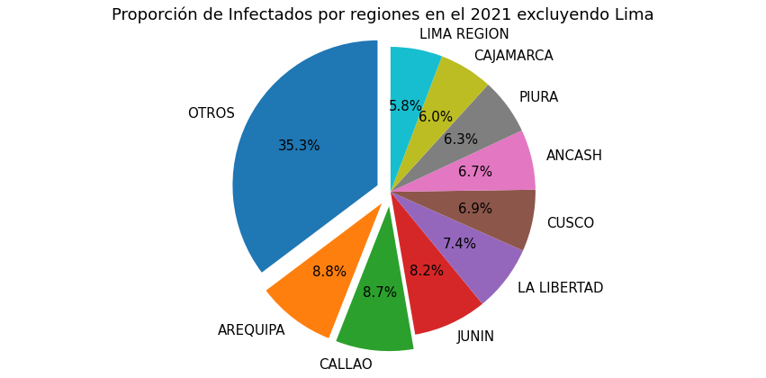

```python
plt.rcParams["figure.figsize"] = (15,7)


fig, ax = plt.subplots()
ax.pie(y, explode=explode, labels=x, autopct='%1.1f%%',
        shadow=False, startangle=90)
ax.axis('equal')  # Equal aspect ratio ensures that pie is drawn as a circle.

ax.set_title("Proporción de Infectados por regiones en el 2021 excluyendo Lima")

plt.show()
```

De acuerdo a este gráfico, las regiones en donde se concentra la mayor cantidad de infectados por COVID-19 son las regiones de Arequipa (8.8%) y Callao (8.7%).